# Quarto presentación

crear archivos quarto en presentación

2024-11-29

# Preparación

## Elección de datos

> boletín de epidemiología correspondiente al mes de junio

**Nota**

Notas que se pueden colocar aparte

## Bullets

Descargar PDF

Además de agregar un boton para la descarga de PDF del material Como lo indica el botón de arriba

Cuando agregamos lineas de este estilo y renderizamos con **Render** se incluyen los botones automanticamente

- Bullet 1
- Bullet 2

## Título de la Diapositiva

Podemos sumar una tabla con estilo personalizado para que quede con color del fondo

Este es el título de la tabla

Y este es el subtítulo que proporciona más contexto

| Columna1 | Columna2 | Columna3 |
| --- | --- | --- |
| Valor1 | Valor2 | Valor3 |
| Valor4 | Valor5 | Valor6 |

[Aquí se pueden poner enlaces](https://ardata-fr.github.io/flextable-book/)

## Achicar tipografía

Poniendo “{.smaller}” en el titulo achicamos la letra de todo el slide

## Ubicación de Notas

Texto de la diapositiva 1 con referencia a la nota <sup>1</sup>.

Texto de la diapositiva 2 con referencia a la nota <sup>2</sup>.

## Ejemplo de gráfico

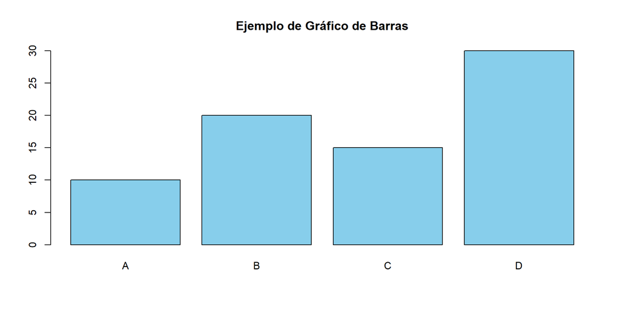

Figura 1: esto es un gráfico de ejemplo

**Gráfico 1**  
Esto es un gráfico de ejemplo que muestra datos ficticios en un gráfico de barras.

## Agregar imágenes en columnas

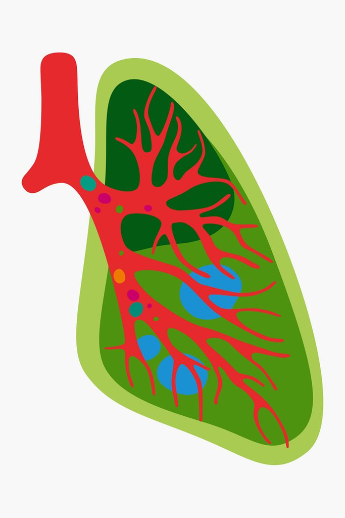

Figura 2: imagen 1

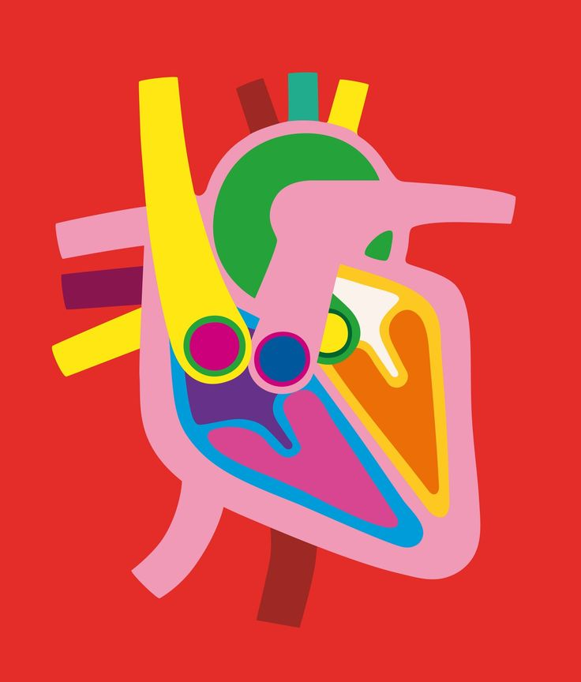

Figura 3: Imagen 2

Y ahora puedo hacer referencia tanto a las imagenes como a los gráficos con los que trabajé como por ejemplo Figura 1 o Figura 3

## Algunos extras

**Caja de avisos**

Se pueden utilizar este tipo de seteos para avisos

Este es un texto destacado o secundario, como una nota al margen.

## Se pueden crear formas

Recuadro exterior

Dirección de Epidemiología